# Interactive COVID-19 Report

Good Morning:

This is your daily COVID-19 report, sent on Friday, January 22, 2021 at 9:04 AM (EST). Shown below is a current **draft** in continual development and error checking. Please feel free to reach out with suggestions or issues! Click here to review the [interactive report](https://jensennhu.github.io/covid_sitrep_auto_prod/). If you’re curious about the situation in other places in the USA (state/county level) or international locations, please click [**here**](http://ec2-3-17-139-199.us-east-2.compute.amazonaws.com:3838/shiny_covid19_aws/).

### USA Overall

> As of yesterday, there has been a total of 24,688,129 cases of COVID-19 in the USA. This is a change of 190,630 (0.78%) new cases since the day prior. The 7 day moving average is currently 1.912e+05 new cases which is a -0.11% change since the day prior and -18.96% change since the week prior. The immediate trend is heading downward. Based on the addition of yesterday’s data, yesterday was not an inflection point (days since last inflection point: 8 –> 2021-01-14).

#### 7-day moving average of new cases in the US (2020-01-21 to 2021-01-21)

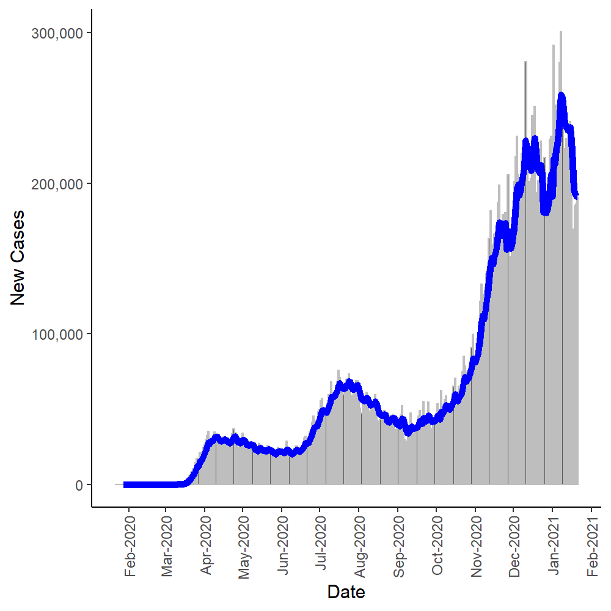

### State Consecutive Day Trends

> Of the 51 US states monitored, **1 (1.96%)** show consecutive increase in their 7-day moving average of new COVID-19 cases for at least 7 days. **41 (80.39%)** show consecutive decrease for at least 7 days.

#### **1** State(s) with Consecutive Increase for at least 7 days

| State | Cases per 100,000 | Consecutive Days |
| --- | --- | --- |
| Virginia | 62 | 21 |

#### **41** State(s) with Consecutive Decrease for at least 7 days

| State | Cases per 100,000 | Consecutive Days |
| --- | --- | --- |
| Arizona | 105 | 7 |
| Rhode Island | 89 | 11 |
| California | 77 | 7 |
| Arkansas | 75 | 9 |
| Georgia | 74 | 7 |
| Kentucky | 70 | 8 |
| Massachusetts | 67 | 8 |
| North Carolina | 65 | 8 |
| Delaware | 65 | 8 |
| Oklahoma | 65 | 7 |
| Mississippi | 63 | 9 |
| Utah | 62 | 8 |
| Connecticut | 62 | 7 |
| New Jersey | 60 | 11 |
| Louisiana | 60 | 9 |
| Tennessee | 56 | 10 |
| Alabama | 56 | 10 |
| West Virginia | 56 | 10 |
| Florida | 56 | 9 |
| Ohio | 54 | 8 |
| Kansas | 53 | 9 |
| Indiana | 50 | 9 |
| Nebraska | 48 | 12 |
| Nevada | 47 | 9 |
| Pennsylvania | 47 | 8 |
| New Mexico | 44 | 9 |
| Idaho | 41 | 11 |
| Iowa | 41 | 10 |
| Illinois | 39 | 9 |
| Wisconsin | 38 | 9 |
| Maryland | 38 | 7 |
| Missouri | 36 | 8 |
| Montana | 35 | 9 |
| South Dakota | 31 | 12 |
| Colorado | 29 | 10 |
| Alaska | 27 | 13 |
| Washington | 26 | 8 |
| Michigan | 25 | 12 |
| Minnesota | 22 | 11 |
| North Dakota | 19 | 11 |
| Hawaii | 8 | 8 |

### Hospital Status (Beta)

> On average, the current stress on ICUs across the country is *extreme*. Stress definitions can be found below:
- **low**: less than 10% of ICU Usage
- **moderate**: 10-29% of ICU Usage
- **high**: 30-59% of ICU Usage
- **extreme**: greater than 60% of ICU Usage

[figure not shown]

### Region by Region

How to read the maps below:

- **Cases Higher**: greater than or equal to 15 new cases per 100,000 people.
- **Cases Lower**: less than 15 new cases per 100,000 people.
- **Rising**: increase in the 7-day moving average, week over week.
- **Decreasing**: decrease in the 7-day moving average, week over week.
- **Staying**: no change in the 7-day moving average, week over weeks

#### **Western US**

[figure not shown]

#### **Southern US**

[figure not shown]

#### **Midwestern US**

[figure not shown]

#### **Northeastern US**

[figure not shown]

### Other resources

Other resources to check out:

- [See How All 50 States Are Reopening (and Closing Again)](https://www.nytimes.com/interactive/2020/us/states-reopen-map-coronavirus.html)
- [NYtimes Visualizations for Case Tracking in U.S.](https://www.nytimes.com/interactive/2020/us/coronavirus-us-cases.html)
- [Coronavirus Drug and Treatment Tracker](https://www.nytimes.com/interactive/2020/science/coronavirus-drugs-treatments.html)
- [Coronavirus Vaccine Tracker](https://www.nytimes.com/interactive/2020/science/coronavirus-vaccine-tracker.html)
- [US Projections](https://covid19.healthdata.org/united-states-of-america?view=total-deaths&tab=trend)

## A closer look at your area(s) of interest:

### Los Angeles County, CA

> As of yesterday, there has been a total of 1,046,424 cases of COVID-19 in Los Angeles County, California. This is a change of 7,929 (0.76%) new cases since the day prior. The 7 day moving average is currently 9,518 new cases which is a -5.27% change since the day prior and -34.96% change since the week prior. The immediate trend is heading downward. Based on the addition of yesterday’s data, yesterday was not an inflection point (days since last inflection point: 7 –> 2021-01-15).

#### 7-day moving average of new cases in Los Angeles County (2020-01-26 to 2021-01-21)

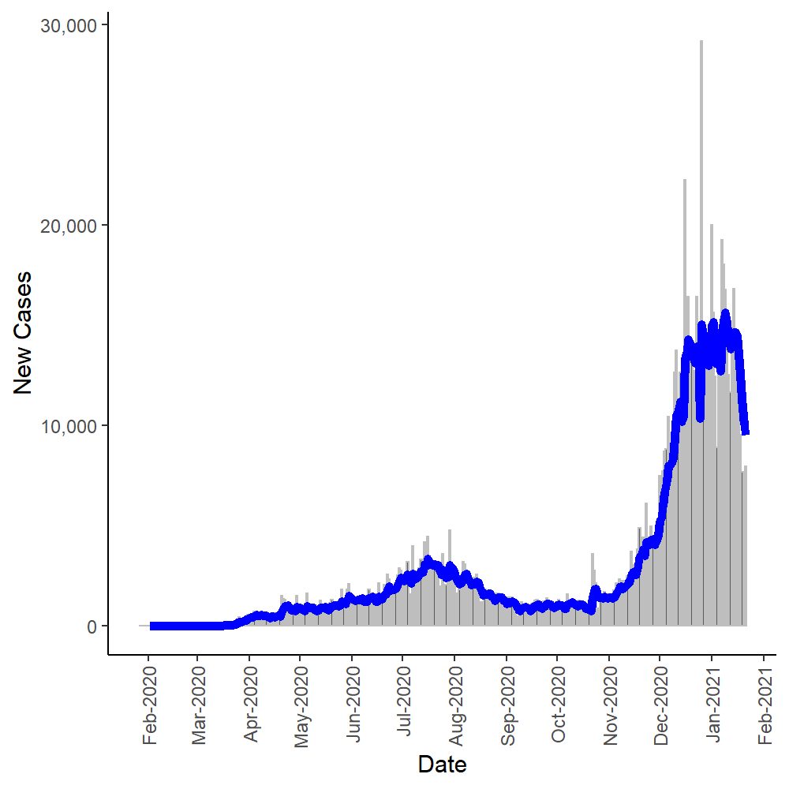

### New York City, NY

> As of yesterday, there has been a total of 551,415 cases of COVID-19 in New York City County, New York. This is a change of 5,220 (0.96%) new cases since the day prior. The 7 day moving average is currently 5,507 new cases which is a -1.71% change since the day prior and -6.5% change since the week prior. The immediate trend is heading downward. Based on the addition of yesterday’s data, yesterday was not an inflection point (days since last inflection point: 2 –> 2021-01-20).

#### 7-day moving average of new cases in New York City (2020-03-01 to 2021-01-21)

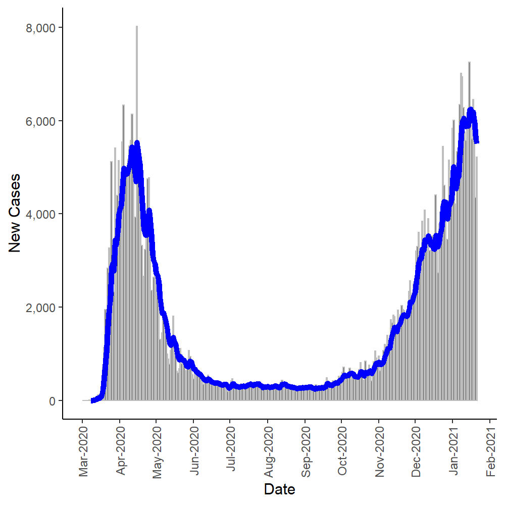

### Chicago (Cook County), IL

> As of yesterday, there has been a total of 439,118 cases of COVID-19 in Cook County, Illinois. This is a change of 1,653 (0.38%) new cases since the day prior. The 7 day moving average is currently 1,747 new cases which is a -1.77% change since the day prior and -25.32% change since the week prior. The immediate trend is heading downward. Based on the addition of yesterday’s data, yesterday was not an inflection point (days since last inflection point: 9 –> 2021-01-13).

#### 7-day moving average of new cases in Chicago (Cook County) (2020-01-24 to 2021-01-21)

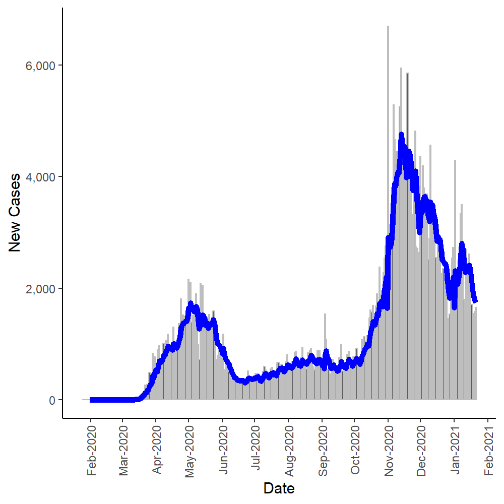

### Boston (Suffolk County), MA

> As of yesterday, there has been a total of 67,004 cases of COVID-19 in Suffolk County, Massachusetts. This is a change of 538 (0.81%) new cases since the day prior. The 7 day moving average is currently 489.3 new cases which is a 3.43% change since the day prior and -23.63% change since the week prior. The immediate trend is heading downward. Based on the addition of yesterday’s data, yesterday was not an inflection point (days since last inflection point: 8 –> 2021-01-14).

#### 7-day moving average of new cases in Boston (Suffolk County) (2020-09-13 to 2021-01-21)

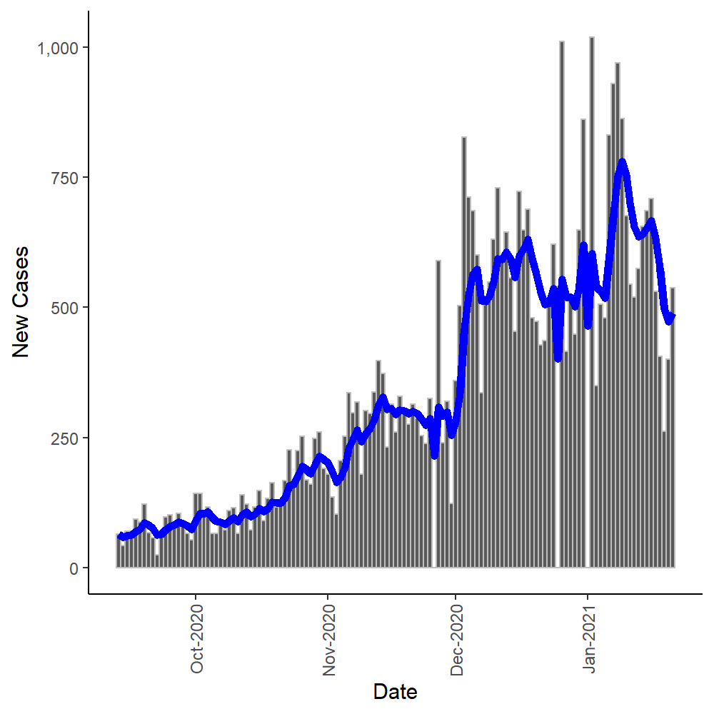

### Seattle (Kings County), WA

> As of yesterday, there has been a total of 74,502 cases of COVID-19 in King County, Washington. This is a change of 423 (0.57%) new cases since the day prior. The 7 day moving average is currently 443.8 new cases which is a -1.53% change since the day prior and -27.9% change since the week prior. The immediate trend is heading downward. Based on the addition of yesterday’s data, yesterday was not an inflection point (days since last inflection point: 7 –> 2021-01-15).

#### 7-day moving average of new cases in Seattle (Kings County) (2020-02-28 to 2021-01-21)

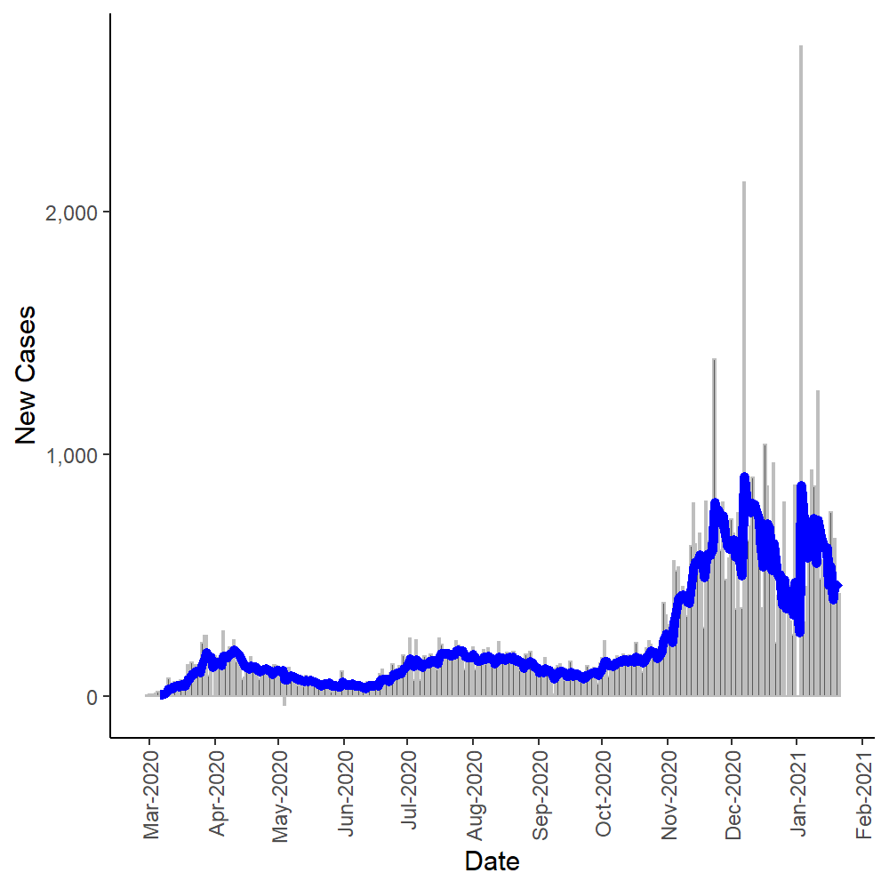

### Hong Kong

> As of yesterday, there has been a total of 9,797 cases of COVID-19 in Hong Kong, China. This is a change of 0 (0%) new cases since the day prior. The 7 day moving average is currently 48.08 new cases which is a -25% change since the day prior and 17.3% change since the week prior. The immediate trend is heading upward. Based on the addition of yesterday’s data, yesterday was not an inflection point (days since last inflection point: 5 –> 2021-01-17).

#### 7-day moving average of new cases in Hong Kong (2020-01-22 to 2021-01-21)

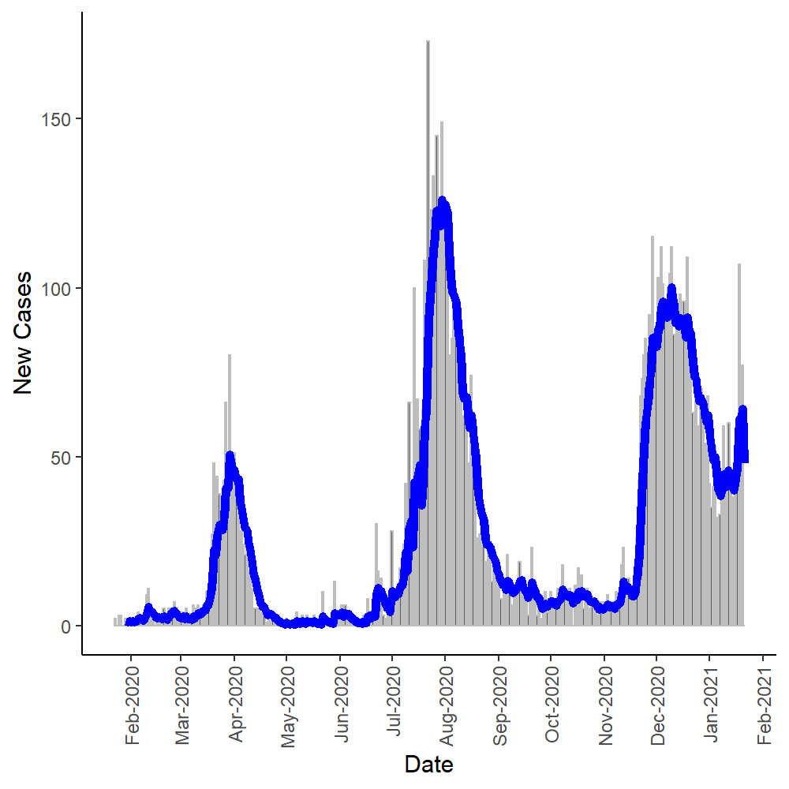

### Shanghai

> As of yesterday, there has been a total of 1,615 cases of COVID-19 in Shanghai, China. This is a change of 0 (0%) new cases since the day prior. The 7 day moving average is currently 4.14 new cases which is a -25% change since the day prior and -8.98% change since the week prior. The immediate trend is heading downward. Based on the addition of yesterday’s data, yesterday (2021-01-21) was an inflection point (days since last inflection point: 2 –> 2021-01-20).

#### 7-day moving average of new cases in Shanghai (2020-01-22 to 2021-01-21)

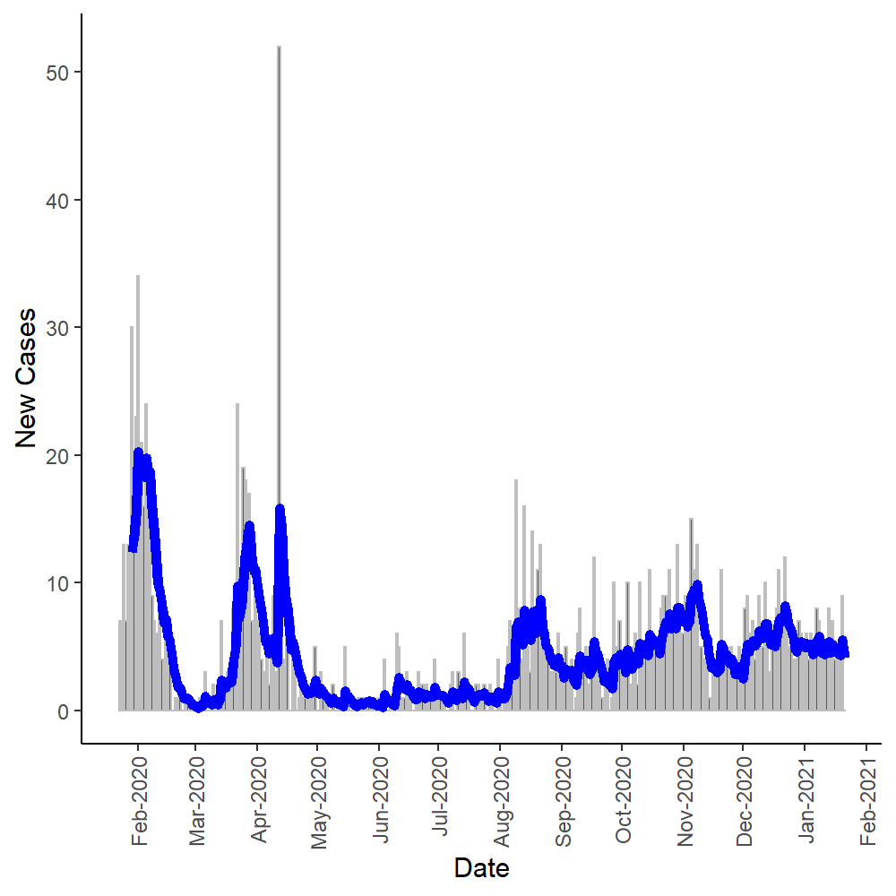